# Algorithmic fairness audit (mini-consulting project)

STATS 369

Yuhui Cao

# Setup

```r
# Load libraries
library(tidyverse)

# read data files
phase1_data = read_csv("data/2022-phase1-new-grad-applicants.csv")
phase2_data = read_csv("data/2022-phase2-new-grad-applicants.csv")
phase3_data = read_csv("data/2022-phase3-new-grad-applicants.csv")
finals_data = read_csv("data/2022-final-hires-newgrad.csv")
```

# Background

A company called Black Saber has been trialling a new AI recruitment pipeline manager for their Data and Software teams. There are three phases, outlined below, each narrowing down the field of applicants. Based on advice from their legal team, they are not able to provide you with the original application data, but they can provide these anonymised indicators/ratings from each phase. `applicant_id` is consistent across phases.

### 1. Wrangle and tidy the datasets

```r
# tidy phase3 data set
phase3_data_pivoted = phase3_data |> pivot_longer(cols=2:23,names_to='id', values_to='rating') |>
  pivot_wider(names_from=applicant_id, values_from = rating)

# convert id type to numeric
phase3_data_pivoted$id = as.numeric(phase3_data_pivoted$id)

# joined the data into one data set
joined_data = full_join(phase1_data,phase2_data) |> full_join(phase3_data_pivoted, by=c("applicant_id" = "id"))

# create indicator variables for passing phase1,2, and 3
joined_data = joined_data |>
  mutate(passedP1 = ifelse(applicant_id %in% phase2_data$applicant_id, "Passed", "Failed"),
         passedP2 = ifelse(applicant_id %in% phase3_data_pivoted$id, "Passed", "Failed"),
         passedP3 = ifelse(applicant_id %in% finals_data$applicant_id,"Passed", "Failed"))

head(joined_data,10)
```

| applicant_id | team_applied_for | cover_letter | cv | gpa | gender | extracurriculars | work_experience | technical_skills | writing_skills | leadership_presence | speaking_skills | interviewer_rating_1 | interviewer_rating_2 | passedP1 | passedP2 | passedP3 |
| --- | --- | --- | --- | --- | --- | --- | --- | --- | --- | --- | --- | --- | --- | --- | --- | --- |
| 1010 | Software | 0 | 1 | 1.3 | Man | 1 | 1 | NA | NA | NA | NA | NA | NA | Failed | Failed | Failed |
| 1020 | Software | 0 | 1 | 3.4 | Woman | 2 | 1 | NA | NA | NA | NA | NA | NA | Failed | Failed | Failed |
| 1030 | Data | 1 | 1 | 2.4 | Woman | 2 | 0 | 56 | 16 | 5 | 2 | NA | NA | Passed | Failed | Failed |
| 1040 | Software | 0 | 1 | 2.7 | Man | 1 | 1 | NA | NA | NA | NA | NA | NA | Failed | Failed | Failed |
| 1050 | Data | 1 | 0 | 2.1 | Prefer not to say | 0 | 1 | NA | NA | NA | NA | NA | NA | Failed | Failed | Failed |
| 1060 | Software | 0 | 1 | 2.6 | Prefer not to say | 1 | 1 | NA | NA | NA | NA | NA | NA | Failed | Failed | Failed |
| 1070 | Software | 1 | 1 | 3.4 | Woman | 1 | 1 | 80 | 37 | 1 | 3 | NA | NA | Passed | Failed | Failed |
| 1080 | Data | 1 | 1 | 2.6 | Man | 1 | 1 | 89 | 48 | 0 | 4 | NA | NA | Passed | Failed | Failed |
| 1090 | Data | 1 | 1 | 3.7 | Man | 2 | 1 | 54 | 60 | 3 | 1 | NA | NA | Passed | Failed | Failed |
| 1100 | Software | 0 | 1 | 2.6 | Woman | 1 | 1 | NA | NA | NA | NA | NA | NA | Failed | Failed | Failed |

### 2. Numeric summary

```r
# filter data to applicants who have passed phase1 and group by gender
filtered_data = joined_data |> filter(passedP1 == "Passed") |> group_by(gender)

# calculate mean for speaking skills assessed by AI
num_summary = filtered_data |>
  summarise(
    count = n(),
    mean = mean(speaking_skills),
    sd = sd(speaking_skills))

# knitr::kable(num_summary)
num_summary
```

| gender | count | mean | sd |
| --- | --- | --- | --- |
| Man | 145 | 5.075862 | 2.392357 |
| Prefer not to say | 3 | 6.666667 | 2.081666 |
| Woman | 152 | 3.309211 | 2.046588 |

From the summary above we see that the average speaking skill rating for men is 5.1 and for women is 3.3. We can also see that the number of observations for those who chose, prefer not to say as their gender was insufficient (3) to make a inference, so we choose to remove it. The mean skill rating for men is higher than woman.

```r
# We see that there is not enough "Prefer not to say" observations so we decide to drop it
filtered_data_new = filtered_data |> filter(gender != "Prefer not to say")

# new numerical summary
num_sum_new = filtered_data_new |>
  summarise(
    count = n(),
    mean = mean(speaking_skills),
    sd = sd(speaking_skills))

# knitr::kable(num_sum_new)
num_sum_new
```

| gender | count | mean | sd |
| --- | --- | --- | --- |
| Man | 145 | 5.075862 | 2.392357 |
| Woman | 152 | 3.309211 | 2.046588 |

### T-test

```r
# perform t-test on speaking skills vs gender
ttest_result = t.test(speaking_skills ~ gender, data = filtered_data_new, var.equal=T)
ttest_result
```

```
##
##  Two Sample t-test
##
## data:  speaking_skills by gender
## t = 6.8488, df = 295, p-value = 4.332e-11
## alternative hypothesis: true difference in means between group Man and group Woman is not equal to 0
## 95 percent confidence interval:
##  1.258995 2.274308
## sample estimates:
##   mean in group Man mean in group Woman
##            5.075862            3.309211
```

We perform a t-test to compare the means between the two groups (Man, Woman) and see that the p-value is 4.332497^{-11} which is below 0.05 meaning that there is evidence to say that there is a difference in mean speaking skill rating between Man and Woman.

### Graphing

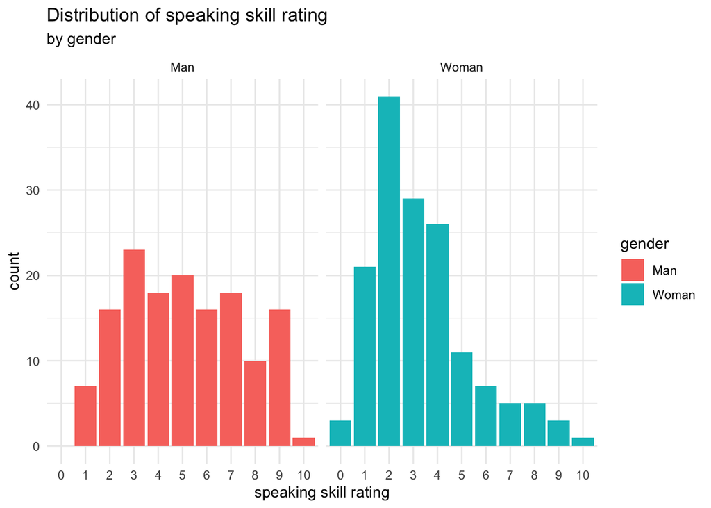

```r
# create bar graph to display the distribution of speaking skill rating between the genders.
filtered_data_new |> ggplot(mapping = aes(x = factor(speaking_skills), fill=gender)) + geom_bar(stat="count") + facet_grid(.~gender) +
  labs(title = "Distribution of speaking skill rating", subtitle="by gender", x = "speaking skill rating", y="count",
       alt = "A bar chart faceted by gender representing the dsitribution of speaking skill ratings. On the x-axis is the speaking skill rating from low (0) to high (10). On the y axis is the count for the number of individuals in each speaking skill rating. The graph shows that for men the skill rating is roughly uniformly dsitributed while for women there are more in the lower skill rating.") + theme_minimal()
```

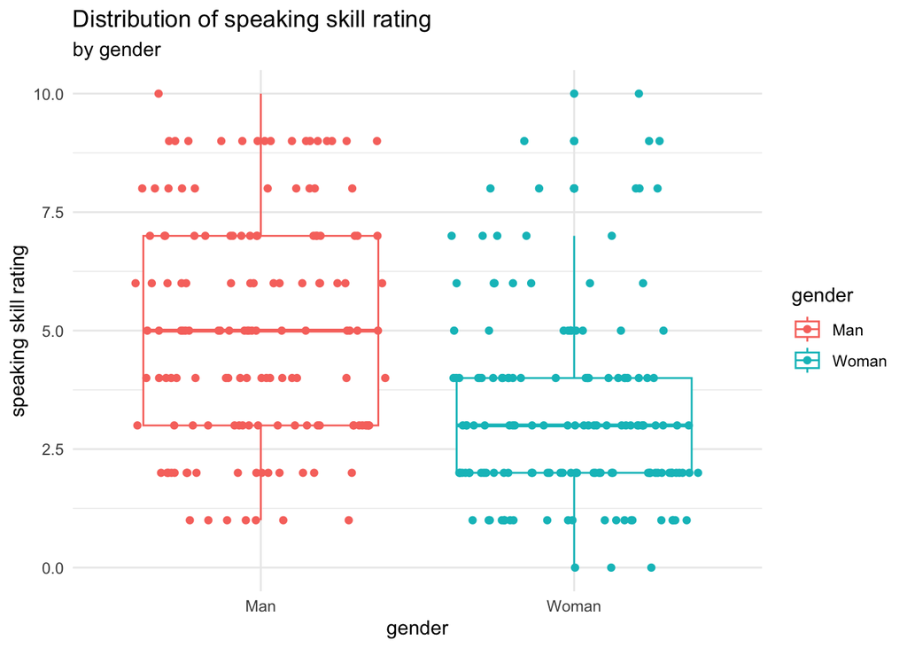

```r
# plot boxplot
filtered_data_new |> ggplot(mapping = aes(x = gender, y = speaking_skills, colour=gender)) + geom_boxplot() +
  labs(title = "Distribution of speaking skill rating", subtitle = "by gender", x = "gender", y = "speaking skill rating") + geom_jitter(height = 0) + theme_minimal()
```

We can see in the bar graph that majority of women applicants have a speaking skill rating that lies between the lower ratings (1-4) while for men they it is roughly evenly distributed from a rating of 2 to 9. On average men are placed higher in speaking skills than woman.

### 3. alt text

alt = “A bar chart faceted by gender representing the dsitribution of speaking skill ratings. On the x-axis is the speaking skill rating from low (0) to high (10). On the y axis is the count for the number of individuals in each speaking skill rating. The graph shows that for men the skill rating is roughly uniformly distributed while for women there are more in the lower skill rating.”

### 4. Conclusion

After reviewing the data from the AI applicant processing system, we found a significant difference in speaking skill ratings between male and female applicants; we removed applicants who preferred not to reveal their gender due to insufficient observations. Our numeric summary found that on average male applicants received a higher speaking skill rating (around 5) than female applicants (around 3). After conducting a statistical analysis we can confirm that this difference was significant, this was further supported from a visualisation which highlights the same points as the numeric summary. Therefore since there was a significant difference between the speaking skill ratings between male and females (with the around the same number of observations) this could be a potential risk of gender bias in the AI model.

# Reflection

1. I showcased the capability of independence and integrity, which is one of the Graduate Capabilities. During the task, I demonstrated my ability to learn and work autonomously by looking up documentation for R code I was unfamiliar with to understand better how to use it, for example, how to check if an applicant id was in another data-set to create an indicator variable to determine if the applicant had passed a phase or not. Although facing some confusion on this task, I showed my resilience and pro-activity by finishing the task while asking for assistance and clarification on anything I found unclear. I demonstrated this capability by making academic and professional decisions, like only asking for assistance after I had tried my attempt at the task or researching independently on online resources (“Graduate profiles - The University of Auckland,” n.d.).
2. I am proud of this project as I have gained a lot of experience with R and data science practice. Although unsure of my overall performance for this assignment , I believe the experience and learning is what matters the most.
3. One thing i would like to do differently in the next project is reach out for help earlier, delayed asking for clarification and help on task 2 until the last opportunity.

# References

1. Graduate profiles - The University of Auckland. (n.d.). Www.auckland.ac.nz. https://www.auckland.ac.nz/en/students/forms-policies-and-guidelines/student-policies-and-guidelines/graduate-profile.html
2. stats369-bolton/Assignments/data at main · elb0/stats369-bolton. (n.d.). GitHub. Retrieved July 28, 2023, from https://github.com/elb0/stats369-bolton/tree/main/Assignments/data